# Melbourne Housing Prices

In this project we are going to explore the housing market for Melbourne from 2016 to 2018. The aim of this project is to help residents in Melbourne better understand how much their property is worth and what factors can increase their property valuation. We will achieve this by creating a model that can accurately evaulate a properties market value based on its attributes.

I will be using the dataset provided on Kaggle (https://www.kaggle.com/datasets/anthonypino/melbourne-housing-market) to understand the housing market in Melbourne. This dataset provides features such as: Number of rooms, price, suburb, number of bedrooms and bathrooms, location and more.

This project only uses Melbourne housing data but once the model has been trained and deemed sucessfull, it can be applied to any location provided they include the same attributes.

*Note: if this model works for Melbourne there is no guarentee that it will be useful for other markets due to location specific trends.*

```python
import numpy as np
import pandas as pd
import matplotlib.pyplot as plt
import seaborn as sns
from sklearn.base import BaseEstimator, TransformerMixin
from sklearn.preprocessing import StandardScaler, OneHotEncoder
from sklearn.pipeline import Pipeline
from sklearn.compose import ColumnTransformer
from sklearn.model_selection import cross_val_score

%matplotlib inline
```

```python
# https://www.kaggle.com/datasets/anthonypino/melbourne-housing-market
DATASET_URL = "./data/melbourne_housing.csv"

df = pd.read_csv(DATASET_URL)
df.head()
```

|  | Suburb | Address | Rooms | Type | Price | Method | SellerG | Date | Distance | Postcode | ... | Bathroom | Car | Landsize | BuildingArea | YearBuilt | CouncilArea | Lattitude | Longtitude | Regionname | Propertycount |
| --- | --- | --- | --- | --- | --- | --- | --- | --- | --- | --- | --- | --- | --- | --- | --- | --- | --- | --- | --- | --- | --- |
| 0 | Abbotsford | 68 Studley St | 2 | h | NaN | SS | Jellis | 3/09/2016 | 2.5 | 3067.0 | ... | 1.0 | 1.0 | 126.0 | NaN | NaN | Yarra City Council | -37.8014 | 144.9958 | Northern Metropolitan | 4019.0 |
| 1 | Abbotsford | 85 Turner St | 2 | h | 1480000.0 | S | Biggin | 3/12/2016 | 2.5 | 3067.0 | ... | 1.0 | 1.0 | 202.0 | NaN | NaN | Yarra City Council | -37.7996 | 144.9984 | Northern Metropolitan | 4019.0 |
| 2 | Abbotsford | 25 Bloomburg St | 2 | h | 1035000.0 | S | Biggin | 4/02/2016 | 2.5 | 3067.0 | ... | 1.0 | 0.0 | 156.0 | 79.0 | 1900.0 | Yarra City Council | -37.8079 | 144.9934 | Northern Metropolitan | 4019.0 |
| 3 | Abbotsford | 18/659 Victoria St | 3 | u | NaN | VB | Rounds | 4/02/2016 | 2.5 | 3067.0 | ... | 2.0 | 1.0 | 0.0 | NaN | NaN | Yarra City Council | -37.8114 | 145.0116 | Northern Metropolitan | 4019.0 |
| 4 | Abbotsford | 5 Charles St | 3 | h | 1465000.0 | SP | Biggin | 4/03/2017 | 2.5 | 3067.0 | ... | 2.0 | 0.0 | 134.0 | 150.0 | 1900.0 | Yarra City Council | -37.8093 | 144.9944 | Northern Metropolitan | 4019.0 |

5 rows × 21 columns

# Data Exploration

```python
# What columns are there and how many of them have null values?
df.info()
```

```
<class 'pandas.core.frame.DataFrame'>
RangeIndex: 34857 entries, 0 to 34856
Data columns (total 21 columns):
 #   Column         Non-Null Count  Dtype
---  ------         --------------  -----
 0   Suburb         34857 non-null  object
 1   Address        34857 non-null  object
 2   Rooms          34857 non-null  int64
 3   Type           34857 non-null  object
 4   Price          27247 non-null  float64
 5   Method         34857 non-null  object
 6   SellerG        34857 non-null  object
 7   Date           34857 non-null  object
 8   Distance       34856 non-null  float64
 9   Postcode       34856 non-null  float64
 10  Bedroom2       26640 non-null  float64
 11  Bathroom       26631 non-null  float64
 12  Car            26129 non-null  float64
 13  Landsize       23047 non-null  float64
 14  BuildingArea   13742 non-null  float64
 15  YearBuilt      15551 non-null  float64
 16  CouncilArea    34854 non-null  object
 17  Lattitude      26881 non-null  float64
 18  Longtitude     26881 non-null  float64
 19  Regionname     34854 non-null  object
 20  Propertycount  34854 non-null  float64
dtypes: float64(12), int64(1), object(8)
memory usage: 5.6+ MB
```

**Suburb Column**

```python
df.Suburb.value_counts()
```

```
Suburb
Reservoir          844
Bentleigh East     583
Richmond           552
Glen Iris          491
Preston            485
                  ...
Belgrave             1
Cranbourne East      1
Yarra Glen           1
Olinda               1
Menzies Creek        1
Name: count, Length: 351, dtype: int64
```

*There seems to be a lot suburbs where only one house is listed. This could impact the performance of the model and should be addressed*

```python
(df.Suburb.value_counts() <= 5).sum()
```

```
52
```

*52 of the suburbs have less than 5 properties in the dataset. It may be worth modifying this column upon further inspection.*

**Council Area Column**

```python
df.CouncilArea.value_counts()
```

```
CouncilArea
Boroondara City Council           3675
Darebin City Council              2851
Moreland City Council             2122
Glen Eira City Council            2006
Melbourne City Council            1952
Banyule City Council              1861
Moonee Valley City Council        1791
Bayside City Council              1764
Brimbank City Council             1593
Monash City Council               1466
Stonnington City Council          1460
Maribyrnong City Council          1451
Port Phillip City Council         1280
Hume City Council                 1214
Yarra City Council                1186
Manningham City Council           1046
Hobsons Bay City Council           942
Kingston City Council              871
Whittlesea City Council            828
Wyndham City Council               624
Whitehorse City Council            618
Maroondah City Council             506
Knox City Council                  371
Greater Dandenong City Council     314
Melton City Council                292
Frankston City Council             290
Casey City Council                 176
Yarra Ranges Shire Council         102
Nillumbik Shire Council             88
Macedon Ranges Shire Council        46
Cardinia Shire Council              41
Mitchell Shire Council              20
Moorabool Shire Council              7
Name: count, dtype: int64
```

**Region Name Column**

```python
df.Regionname.value_counts()
```

```
Regionname
Southern Metropolitan         11836
Northern Metropolitan          9557
Western Metropolitan           6799
Eastern Metropolitan           4377
South-Eastern Metropolitan     1739
Eastern Victoria                228
Northern Victoria               203
Western Victoria                115
Name: count, dtype: int64
```

**Type Column**

```python
df.Type.value_counts()
```

```
Type
h    23980
u     7297
t     3580
Name: count, dtype: int64
```

*There is a large number of null building area values. Does it indicate that a type of property will have a null building area?*

```python
df[df.BuildingArea.isnull()].Type.value_counts()
```

```
Type
h    13567
u     5100
t     2448
Name: count, dtype: int64
```

**Overview**

```python
df.describe()
```

|  | Rooms | Price | Distance | Postcode | Bedroom2 | Bathroom | Car | Landsize | BuildingArea | YearBuilt | Lattitude | Longtitude | Propertycount |
| --- | --- | --- | --- | --- | --- | --- | --- | --- | --- | --- | --- | --- | --- |
| count | 34857.000000 | 2.724700e+04 | 34856.000000 | 34856.000000 | 26640.000000 | 26631.000000 | 26129.000000 | 23047.000000 | 13742.00000 | 15551.000000 | 26881.000000 | 26881.000000 | 34854.000000 |
| mean | 3.031012 | 1.050173e+06 | 11.184929 | 3116.062859 | 3.084647 | 1.624798 | 1.728845 | 593.598993 | 160.25640 | 1965.289885 | -37.810634 | 145.001851 | 7572.888306 |
| std | 0.969933 | 6.414671e+05 | 6.788892 | 109.023903 | 0.980690 | 0.724212 | 1.010771 | 3398.841946 | 401.26706 | 37.328178 | 0.090279 | 0.120169 | 4428.090313 |
| min | 1.000000 | 8.500000e+04 | 0.000000 | 3000.000000 | 0.000000 | 0.000000 | 0.000000 | 0.000000 | 0.00000 | 1196.000000 | -38.190430 | 144.423790 | 83.000000 |
| 25% | 2.000000 | 6.350000e+05 | 6.400000 | 3051.000000 | 2.000000 | 1.000000 | 1.000000 | 224.000000 | 102.00000 | 1940.000000 | -37.862950 | 144.933500 | 4385.000000 |
| 50% | 3.000000 | 8.700000e+05 | 10.300000 | 3103.000000 | 3.000000 | 2.000000 | 2.000000 | 521.000000 | 136.00000 | 1970.000000 | -37.807600 | 145.007800 | 6763.000000 |
| 75% | 4.000000 | 1.295000e+06 | 14.000000 | 3156.000000 | 4.000000 | 2.000000 | 2.000000 | 670.000000 | 188.00000 | 2000.000000 | -37.754100 | 145.071900 | 10412.000000 |
| max | 16.000000 | 1.120000e+07 | 48.100000 | 3978.000000 | 30.000000 | 12.000000 | 26.000000 | 433014.000000 | 44515.00000 | 2106.000000 | -37.390200 | 145.526350 | 21650.000000 |

**Some things to note when looking at the data above:**  
• The minimum Bedroom value in the data is 0. This seems interesting and further look into why a property would have no bedrooms.  
• Landsize and building area with a value of 0. Could this indicate incorrect data?  
• Year built has a maximum value of 2106 which is in the future. Are there more data points like this or could it be a typo?

```python
#check for duplicates
df[df.duplicated(keep=False)]
```

|  | Suburb | Address | Rooms | Type | Price | Method | SellerG | Date | Distance | Postcode | ... | Bathroom | Car | Landsize | BuildingArea | YearBuilt | CouncilArea | Lattitude | Longtitude | Regionname | Propertycount |
| --- | --- | --- | --- | --- | --- | --- | --- | --- | --- | --- | --- | --- | --- | --- | --- | --- | --- | --- | --- | --- | --- |
| 15857 | Nunawading | 1/7 Lilian St | 3 | t | NaN | SP | Jellis | 17/06/2017 | 15.4 | 3131.0 | ... | 3.0 | 2.0 | 405.0 | 226.0 | 2000.0 | Manningham City Council | -37.82678 | 145.16777 | Eastern Metropolitan | 4973.0 |
| 15858 | Nunawading | 1/7 Lilian St | 3 | t | NaN | SP | Jellis | 17/06/2017 | 15.4 | 3131.0 | ... | 3.0 | 2.0 | 405.0 | 226.0 | 2000.0 | Manningham City Council | -37.82678 | 145.16777 | Eastern Metropolitan | 4973.0 |

2 rows × 21 columns

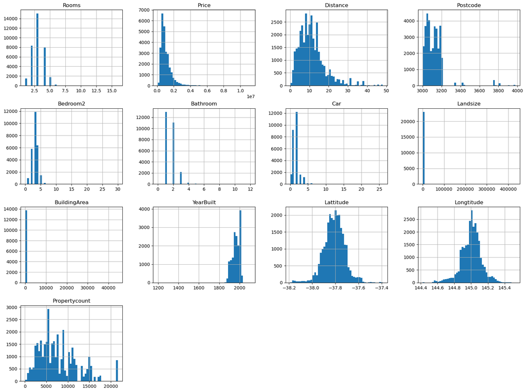

```python
df.hist(bins=50, figsize=(20, 15))
plt.show()
```

*The building area and landsize have a disproportionate amount of null values with huge maximum values. This could either be a good indicator for price or suggest that these columns need to be dropped.*

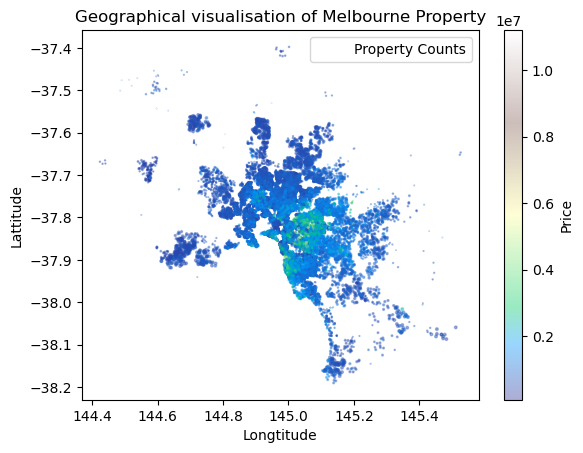

```python
df.plot(kind="scatter", x="Longtitude", y="Lattitude", title="Geographical visualisation of Melbourne Property", alpha=0.4, s=df["Propertycount"]/5000, label="Property Counts", c="Price", cmap=plt.get_cmap("terrain"), colorbar=True);
```

```python
df.corr(numeric_only=True)["Price"].sort_values(ascending=False)
```

```
Price            1.000000
Rooms            0.465238
Bedroom2         0.430275
Bathroom         0.429878
Car              0.201803
Longtitude       0.197874
BuildingArea     0.100754
Postcode         0.044950
Landsize         0.032748
Propertycount   -0.059017
Distance        -0.211384
Lattitude       -0.215607
YearBuilt       -0.333306
Name: Price, dtype: float64
```

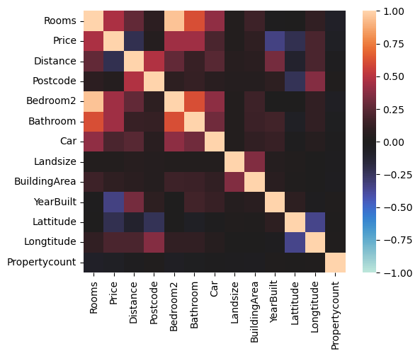

```python
sns.heatmap(df.corr(numeric_only=True), vmin=-1, vmax=1, center=0, square=True);
```

# Data Cleaning

### 1. Drop duplicate row

```python
df_clean = df.drop_duplicates()
```

### 2. Drop data that don't make sense to train the model on

*The columns below have been identified as columns that don't make sense to train the model on. They either provide listing specific details (such as Address, Postcode) which shouldn't be used to predict the price of a property or contain information that is not directly related to the property (Method and SellerG columns).*

```python
df_clean = df_clean.drop(["Address", "Method", "SellerG", "Postcode", "CouncilArea"], axis=1)
```

#### Look for predominantly null columns and rows to drop

```python
df_clean.isnull().sum()
```

```
Suburb               0
Rooms                0
Type                 0
Price             7609
Date                 0
Distance             1
Bedroom2          8217
Bathroom          8226
Car               8728
Landsize         11810
BuildingArea     21115
YearBuilt        19306
Lattitude         7976
Longtitude        7976
Regionname           3
Propertycount        3
dtype: int64
```

*Drop all the rows with missing price values as it will be our target variable*

```python
df_clean.dropna(subset=["Price"], inplace=True)
```

```python
# There are 3 rows containing missing values for the Regionname and Propertycount columns. Are these the same rows?
df_clean[df_clean.Regionname.isnull() & df_clean.Propertycount.isnull()]
```

|  | Suburb | Rooms | Type | Price | Date | Distance | Bedroom2 | Bathroom | Car | Landsize | BuildingArea | YearBuilt | Lattitude | Longtitude | Regionname | Propertycount |
| --- | --- | --- | --- | --- | --- | --- | --- | --- | --- | --- | --- | --- | --- | --- | --- | --- |
| 18523 | Footscray | 2 | u | 710000.0 | 15/07/2017 | 5.1 | NaN | NaN | NaN | NaN | NaN | NaN | NaN | NaN | NaN | NaN |
| 26888 | Camberwell | 2 | h | 825000.0 | 11/11/2017 | 7.7 | NaN | NaN | NaN | NaN | NaN | NaN | NaN | NaN | NaN | NaN |
| 29483 | Fawkner Lot | 3 | h | 616000.0 | 6/01/2018 | NaN | NaN | NaN | NaN | NaN | NaN | NaN | NaN | NaN | NaN | NaN |

*Drop these rows as they don't offer enough insight*

```python
df_clean.dropna(subset=["Bedroom2", "Bathroom", "Car", "Landsize", "BuildingArea", "YearBuilt", "Lattitude", "Longtitude", "Regionname", "Propertycount"], how="all", inplace=True)
```

```python
df_clean.isnull().sum()
```

```
Suburb               0
Rooms                0
Type                 0
Price                0
Date                 0
Distance             0
Bedroom2          6438
Bathroom          6444
Car               6821
Landsize          9262
BuildingArea     16588
YearBuilt        15160
Lattitude         6251
Longtitude        6251
Regionname           0
Propertycount        0
dtype: int64
```

### 3. Imputing Missing Values

#### Dealing with missing values for types of rooms (Bedroom, Bathroom, Car)

```python
df_clean[df_clean["Bedroom2"].isnull() & df_clean["Bathroom"].isnull()].head()
```

|  | Suburb | Rooms | Type | Price | Date | Distance | Bedroom2 | Bathroom | Car | Landsize | BuildingArea | YearBuilt | Lattitude | Longtitude | Regionname | Propertycount |
| --- | --- | --- | --- | --- | --- | --- | --- | --- | --- | --- | --- | --- | --- | --- | --- | --- |
| 15 | Abbotsford | 3 | h | 1000000.0 | 8/10/2016 | 2.5 | NaN | NaN | NaN | NaN | NaN | NaN | NaN | NaN | Northern Metropolitan | 4019.0 |
| 16 | Abbotsford | 2 | t | 745000.0 | 8/10/2016 | 2.5 | NaN | NaN | NaN | NaN | NaN | NaN | NaN | NaN | Northern Metropolitan | 4019.0 |
| 19 | Abbotsford | 2 | u | 542000.0 | 8/10/2016 | 2.5 | NaN | NaN | NaN | NaN | NaN | NaN | NaN | NaN | Northern Metropolitan | 4019.0 |
| 21 | Abbotsford | 2 | u | 760000.0 | 10/12/2016 | 2.5 | NaN | NaN | NaN | NaN | NaN | NaN | NaN | NaN | Northern Metropolitan | 4019.0 |
| 22 | Abbotsford | 1 | u | 481000.0 | 10/12/2016 | 2.5 | NaN | NaN | NaN | NaN | NaN | NaN | NaN | NaN | Northern Metropolitan | 4019.0 |

*Looking at the data above. There seems to be a large amount of rows that are missing most of their column values. These rows should also be dropped as there would be too many data points that would need to be imputed and would therefor mean that a lot of the rows are synthetic.*

```python
df_clean.dropna(subset=["Bedroom2", "Bathroom", "Car", "Landsize", "BuildingArea", "YearBuilt"], how="all", inplace=True)
```

```python
df_clean.isnull().sum()
```

```
Suburb               0
Rooms                0
Type                 0
Price                0
Date                 0
Distance             0
Bedroom2             6
Bathroom            12
Car                389
Landsize          2830
BuildingArea     10156
YearBuilt         8728
Lattitude           22
Longtitude          22
Regionname           0
Propertycount        0
dtype: int64
```

##### Bedrooms Feature

```python
df_clean[df_clean["Bedroom2"].isnull()]
```

|  | Suburb | Rooms | Type | Price | Date | Distance | Bedroom2 | Bathroom | Car | Landsize | BuildingArea | YearBuilt | Lattitude | Longtitude | Regionname | Propertycount |
| --- | --- | --- | --- | --- | --- | --- | --- | --- | --- | --- | --- | --- | --- | --- | --- | --- |
| 24807 | Wollert | 4 | h | 335000.0 | 14/10/2017 | 25.5 | NaN | NaN | NaN | 446.0 | NaN | NaN | -37.61939 | 145.03831 | Northern Metropolitan | 2940.0 |
| 26177 | Mentone | 1 | u | 385000.0 | 28/10/2017 | 20.0 | NaN | NaN | NaN | 239.0 | NaN | NaN | -37.98223 | 145.06781 | South-Eastern Metropolitan | 6162.0 |
| 27157 | Mentone | 5 | h | 1200000.0 | 11/11/2017 | 20.0 | NaN | NaN | NaN | 594.0 | NaN | NaN | -37.97700 | 145.07880 | South-Eastern Metropolitan | 6162.0 |
| 29197 | Williamstown | 3 | h | 1145000.0 | 25/11/2017 | 6.8 | NaN | NaN | NaN | 549.0 | NaN | NaN | -37.85250 | 144.88720 | Western Metropolitan | 6380.0 |
| 34114 | Cheltenham | 2 | t | 682000.0 | 24/02/2018 | 17.9 | NaN | NaN | NaN | 338.0 | NaN | NaN | -37.97144 | 145.07268 | Southern Metropolitan | 9758.0 |
| 34149 | Craigieburn | 3 | h | 438000.0 | 24/02/2018 | 20.6 | NaN | NaN | NaN | 250.0 | NaN | NaN | -37.59889 | 144.89668 | Northern Metropolitan | 15510.0 |

```python
diff_rooms = df_clean["Rooms"] - df_clean["Bedroom2"]
```

```python
f"{int(diff_rooms.sum())}/{diff_rooms.shape[0]} rows have a room value that is different from the bedroom value."
```

```
'314/20812 rows have a room value that is different from the bedroom value.'
```

99% of the properties in the dataset have the same value for the Rooms column as they do for the Bedroom2 column. I am going to use this to impute the missing values for the Bedroom2 column with the Rooms column.

```python
mask = df_clean["Bedroom2"].isnull()
df_clean.loc[mask, 'Bedroom2'] = df_clean['Rooms']
```

##### Bathrooms Feature

We are going to fill the missing values for the bathroom column by using the Bedroom2 column and finding the average number of bathrooms for the number of bedrooms. So we will be able to impute the value by getting the number of Bedrooms (e.g. 4) and finding what the average number of bathrooms there are for all the 4 bedroom properties in the dataset.

```python
bathroom_map = df_clean.groupby(by=["Bedroom2"])[["Bathroom"]].mean()

def get_bathroom(x):
    bedroom_num = x.Bedroom2
    x.Bathroom = round(bathroom_map.loc[bedroom_num].Bathroom)
    return x
```

```python
df_clean[df_clean["Bathroom"].isnull()] = df_clean[df_clean["Bathroom"].isnull()].apply(get_bathroom, axis=1)
```

##### Car Feature

We will apply the same process above to the Car column however with the addition of another column when determining the average. We will be using both the Rooms column and the Bedroom2 column to determine the Car value. I chose these two columns based on the correlation matrix in the data exploration section.

```python
car_map = df_clean.groupby(by=["Rooms", "Bedroom2"])[["Car"]].mean()

def get_car(x):
    room_num = x.Rooms
    bedroom_num = x.Bedroom2
    x.Car = round(car_map.loc[room_num, bedroom_num].Car)
    return x
```

```python
df_clean[df_clean["Car"].isnull()] = df_clean[df_clean["Car"].isnull()].apply(get_car, axis=1)
```

```python
df_clean.isnull().sum()
```

```
Suburb               0
Rooms                0
Type                 0
Price                0
Date                 0
Distance             0
Bedroom2             0
Bathroom             0
Car                  0
Landsize          2830
BuildingArea     10156
YearBuilt         8728
Lattitude           22
Longtitude          22
Regionname           0
Propertycount        0
dtype: int64
```

#### Dealing with missing location values

```python
df_clean[(df_clean["Lattitude"].isnull()) & (df_clean["Longtitude"].isnull())].head()
```

|  | Suburb | Rooms | Type | Price | Date | Distance | Bedroom2 | Bathroom | Car | Landsize | BuildingArea | YearBuilt | Lattitude | Longtitude | Regionname | Propertycount |
| --- | --- | --- | --- | --- | --- | --- | --- | --- | --- | --- | --- | --- | --- | --- | --- | --- |
| 2572 | Burwood | 3 | h | 990000.0 | 17/09/2016 | 11.7 | 3.0 | 2.0 | 2.0 | 263.0 | NaN | NaN | NaN | NaN | Southern Metropolitan | 5678.0 |
| 3257 | Clifton Hill | 1 | u | 363000.0 | 27/06/2016 | 3.4 | 1.0 | 1.0 | 1.0 | 0.0 | NaN | NaN | NaN | NaN | Northern Metropolitan | 2954.0 |
| 4485 | Footscray | 3 | t | 781000.0 | 27/11/2016 | 6.4 | 3.0 | 2.0 | 2.0 | 98.0 | 169.0 | 2015.0 | NaN | NaN | Western Metropolitan | 7570.0 |
| 5170 | Hampton East | 4 | t | 1185000.0 | 28/05/2016 | 14.5 | 4.0 | 3.0 | 1.0 | 300.0 | NaN | NaN | NaN | NaN | Southern Metropolitan | 2356.0 |
| 10745 | Williamstown North | 1 | u | 355000.0 | 27/11/2016 | 8.9 | 1.0 | 1.0 | 1.0 | 46.0 | 46.0 | NaN | NaN | NaN | Western Metropolitan | 802.0 |

There are very few missing values for longitude and latitude. All the rows that have a missing longitude value also have a missing latitude value (and vice versa); I will impute the property location from the Suburb and it's corresponding longitude and latitude (Manually built from Google Maps).

Because there are such few missing values, this should not effect the distribution of the property locations while still keeping the longitude and latitude columns.

##### Build Dictionary that maps Suburb to its corresponding location

```python
df_clean[(df_clean["Lattitude"].isnull()) & (df_clean["Longtitude"].isnull())].Suburb.unique()
```

```
array(['Burwood', 'Clifton Hill', 'Footscray', 'Hampton East',
       'Williamstown North', 'Melbourne', 'Brooklyn', 'North Melbourne',
       'Oakleigh South', 'Essendon', 'Seddon', 'Croydon', 'Kensington',
       'Strathmore', 'Keysborough', 'Lalor', 'Mickleham', 'Wollert',
       'Greenvale'], dtype=object)
```

```python
suburb_location_map = {"Burwood": {"latitude": -37.84879, "longitude": 145.10812},
                        "Clifton Hill": {"latitude": -37.78758, "longitude": 144.99984},
                        "Footscray": {"latitude": -37.79862, "longitude": 144.89782},
                        "Hampton East": {"latitude": -37.93836, "longitude": 145.03155},
                        "Williamstown North": {"latitude": -37.85173, "longitude": 144.86235},
                        "Melbourne": {"latitude": -37.81394, "longitude": 144.96572},
                        "Brooklyn": {"latitude": -37.81746, "longitude": 144.84659},
                       "North Melbourne": {"latitude": -37.80090, "longitude": 144.94888},
                       "Oakleigh South": {"latitude": -37.92603, "longitude": 145.09528},
                       "Essendon": {"latitude": -37.75286, "longitude": 144.91533},
                       "Seddon": {"latitude": -37.80671, "longitude": 144.89225},
                       "Croydon": {"latitude": -37.79465, "longitude": 145.28255},
                       "Kensington": {"latitude": -37.79404, "longitude": 144.92778},
                       "Strathmore": {"latitude": -37.73414, "longitude": 144.91948},
                       "Keysborough": {"latitude": -37.99932, "longitude": 145.17356},
                       "Lalor": {"latitude": -37.66561, "longitude": 145.01678},
                       "Mickleham": {"latitude": -37.53447, "longitude": 144.90723},
                       "Wollert": {"latitude": -37.60879, "longitude": 145.03201},
                       "Greenvale": {"latitude": -37.63989, "longitude": 144.88238},
                      }
```

##### Map locations to null values

```python
def fill_lat_lon(x):
    sub = suburb_location_map[x.Suburb]
    x.Lattitude = sub['latitude']
    x.Longtitude = sub['longitude']
    return x

df_clean[(df_clean["Lattitude"].isnull()) & (df_clean["Longtitude"].isnull())] = df_clean[(df_clean["Lattitude"].isnull()) & (df_clean["Longtitude"].isnull())].apply(fill_lat_lon ,axis=1)
```

```python
df_clean.isnull().sum()
```

```
Suburb               0
Rooms                0
Type                 0
Price                0
Date                 0
Distance             0
Bedroom2             0
Bathroom             0
Car                  0
Landsize          2830
BuildingArea     10156
YearBuilt         8728
Lattitude            0
Longtitude           0
Regionname           0
Propertycount        0
dtype: int64
```

#### Dealing with Landsize and building area

```python
print(f"Proportion of missing building area values: {round(df_clean.BuildingArea.isnull().sum() / df_clean.shape[0], 2)}\n")

df_clean[df_clean.BuildingArea.isnull()].head()
```

```
Proportion of missing building area values: 0.49
```

|  | Suburb | Rooms | Type | Price | Date | Distance | Bedroom2 | Bathroom | Car | Landsize | BuildingArea | YearBuilt | Lattitude | Longtitude | Regionname | Propertycount |
| --- | --- | --- | --- | --- | --- | --- | --- | --- | --- | --- | --- | --- | --- | --- | --- | --- |
| 1 | Abbotsford | 2 | h | 1480000.0 | 3/12/2016 | 2.5 | 2.0 | 1.0 | 1.0 | 202.0 | NaN | NaN | -37.7996 | 144.9984 | Northern Metropolitan | 4019.0 |
| 5 | Abbotsford | 3 | h | 850000.0 | 4/03/2017 | 2.5 | 3.0 | 2.0 | 1.0 | 94.0 | NaN | NaN | -37.7969 | 144.9969 | Northern Metropolitan | 4019.0 |
| 10 | Abbotsford | 2 | h | 941000.0 | 7/05/2016 | 2.5 | 2.0 | 1.0 | 0.0 | 181.0 | NaN | NaN | -37.8041 | 144.9953 | Northern Metropolitan | 4019.0 |
| 17 | Abbotsford | 1 | u | 300000.0 | 8/10/2016 | 2.5 | 1.0 | 1.0 | 1.0 | 0.0 | NaN | NaN | -37.8008 | 144.9973 | Northern Metropolitan | 4019.0 |
| 23 | Abbotsford | 2 | u | 700000.0 | 12/11/2016 | 2.5 | 2.0 | 2.0 | 1.0 | 0.0 | NaN | NaN | -37.8110 | 145.0067 | Northern Metropolitan | 4019.0 |

With almost 50% of the rows missing a BuildingArea value, it would be safe to drop this column as we would not be able to impute a semi-accurate value for the missing rows. However, there is potential to use this column to help impute the Landsize column for missing values.

```python
missing_landsize = (df_clean.Landsize.isnull()) | (df_clean.Landsize == 0)
print(df_clean.loc[missing_landsize].shape)
df_clean.loc[missing_landsize].head()
```

```
(4772, 16)
```

|  | Suburb | Rooms | Type | Price | Date | Distance | Bedroom2 | Bathroom | Car | Landsize | BuildingArea | YearBuilt | Lattitude | Longtitude | Regionname | Propertycount |
| --- | --- | --- | --- | --- | --- | --- | --- | --- | --- | --- | --- | --- | --- | --- | --- | --- |
| 17 | Abbotsford | 1 | u | 300000.0 | 8/10/2016 | 2.5 | 1.0 | 1.0 | 1.0 | 0.0 | NaN | NaN | -37.8008 | 144.9973 | Northern Metropolitan | 4019.0 |
| 23 | Abbotsford | 2 | u | 700000.0 | 12/11/2016 | 2.5 | 2.0 | 2.0 | 1.0 | 0.0 | NaN | NaN | -37.8110 | 145.0067 | Northern Metropolitan | 4019.0 |
| 25 | Abbotsford | 2 | u | 750000.0 | 12/11/2016 | 2.5 | 2.0 | 2.0 | 1.0 | 0.0 | 94.0 | 2009.0 | -37.8078 | 144.9965 | Northern Metropolitan | 4019.0 |
| 29 | Abbotsford | 1 | u | 441000.0 | 14/05/2016 | 2.5 | 1.0 | 1.0 | 1.0 | 0.0 | NaN | NaN | -37.8016 | 144.9988 | Northern Metropolitan | 4019.0 |
| 40 | Abbotsford | 3 | t | 900000.0 | 18/03/2017 | 2.5 | 3.0 | 2.0 | 2.0 | 0.0 | NaN | 2010.0 | -37.8093 | 144.9959 | Northern Metropolitan | 4019.0 |

##### Fill in the missing Landsize value with the BuildingArea

```python
df_clean.loc[missing_landsize, "Landsize"] = df_clean['BuildingArea']
df_clean[(df_clean.Landsize.isnull()) | (df_clean.Landsize == 0)].shape
```

```
(2449, 16)
```

##### Drop the BuildingArea column

```python
df_clean.drop("BuildingArea",axis=1, inplace=True)
```

##### Impute the final missing values for the Landsize column

To impute the final missing values for the Landsize column. We are going to use the average Landsize based on the type of property and the number of rooms to determine the new value for the row.

```python
landsize_map = df_clean.groupby(by=["Type", "Rooms"])[["Landsize"]].mean()

def get_landsize(x):
    pType = x.Type
    rooms_num = x.Rooms
    if (np.isnan(landsize_map.loc[pType, rooms_num].Landsize)):
        x.Landsize = df_clean.Landsize.mean()
    else:
        x.Landsize = round(landsize_map.loc[pType, rooms_num].Landsize)

    return x
```

```python
df_clean[(df_clean.Landsize.isnull()) | (df_clean.Landsize == 0)] = df_clean[(df_clean.Landsize.isnull()) | (df_clean.Landsize == 0)].apply(get_landsize, axis=1)
```

```python
df_clean.isnull().sum()
```

```
Suburb              0
Rooms               0
Type                0
Price               0
Date                0
Distance            0
Bedroom2            0
Bathroom            0
Car                 0
Landsize            0
YearBuilt        8728
Lattitude           0
Longtitude          0
Regionname          0
Propertycount       0
dtype: int64
```

#### Modifying the YearBuilt column

The YearBuilt column has quite a few missing values and would suggest that this column be dropped however, based on the correlation matrix in the data exploration section, the year the building was built (or better yet, the property's age) seems to play a significant role in determining the price.

A proposed solution is to convert the YearBuilt column into a categorical representation of the property age and include a category for if the YearBuilt was missing.

```python
df_clean["YearBuilt"].describe()
```

```
count    12084.000000
mean      1966.609153
std         36.762373
min       1196.000000
25%       1950.000000
50%       1970.000000
75%       2000.000000
max       2019.000000
Name: YearBuilt, dtype: float64
```

```python
def categorize_year(x):
    if np.isnan(x):
        return np.nan

    if x >= 2000:
        return "2000-2020"

    if x < 2000 and x >= 1980:
        return "1980-1999"

    if x < 1980 and x >= 1960:
        return "1960-1979"

    if x < 1960 and x >= 1940:
        return "1940-1959"

    return "before 1940"
```

```python
df_clean["PeriodBuilt"] =  df_clean.YearBuilt.apply(categorize_year)
```

```python
df_clean.PeriodBuilt.value_counts()
```

```
PeriodBuilt
2000-2020      3130
1960-1979      3081
before 1940    2542
1980-1999      1864
1940-1959      1467
Name: count, dtype: int64
```

```python
# drop the YearBuilt Column
df_clean.drop("YearBuilt", axis=1, inplace=True)
```

```python
df_clean.isnull().sum()
```

```
Suburb              0
Rooms               0
Type                0
Price               0
Date                0
Distance            0
Bedroom2            0
Bathroom            0
Car                 0
Landsize            0
Lattitude           0
Longtitude          0
Regionname          0
Propertycount       0
PeriodBuilt      8728
dtype: int64
```

### 4. Transforming Date column

Currently, the Date column is a string object and should be converted into a form that can be used to perform model training on. The date itself doesn't seem to be that usefull but the year the property was sold could offer some value.

```python
# Convert the Date to the year the property was sold.
df_clean["YearSold"] = pd.to_numeric(df_clean.Date.str[-4:])

df_clean.drop("Date", axis=1, inplace=True)
```

```python
df_clean.YearSold.isnull().sum()
```

```
0
```

### 5. One-hot Encoding Categorical Attributes

```python
df_clean = pd.get_dummies(df_clean)
```

### 6. Create cleaning pipeline

```python
class CleanHousingData(BaseEstimator, TransformerMixin):
    # Map of Suburbs and their centre location
    suburb_location_map = {
            "Burwood": {"latitude": -37.84879, "longitude": 145.10812},
            "Clifton Hill": {"latitude": -37.78758, "longitude": 144.99984},
            "Footscray": {"latitude": -37.79862, "longitude": 144.89782},
            "Hampton East": {"latitude": -37.93836, "longitude": 145.03155},
            "Williamstown North": {"latitude": -37.85173, "longitude": 144.86235},
            "Melbourne": {"latitude": -37.81394, "longitude": 144.96572},
            "Brooklyn": {"latitude": -37.81746, "longitude": 144.84659},
            "North Melbourne": {"latitude": -37.80090, "longitude": 144.94888},
            "Oakleigh South": {"latitude": -37.92603, "longitude": 145.09528},
            "Essendon": {"latitude": -37.75286, "longitude": 144.91533},
            "Seddon": {"latitude": -37.80671, "longitude": 144.89225},
            "Croydon": {"latitude": -37.79465, "longitude": 145.28255},
            "Kensington": {"latitude": -37.79404, "longitude": 144.92778},
            "Strathmore": {"latitude": -37.73414, "longitude": 144.91948},
            "Keysborough": {"latitude": -37.99932, "longitude": 145.17356},
            "Lalor": {"latitude": -37.66561, "longitude": 145.01678},
            "Mickleham": {"latitude": -37.53447, "longitude": 144.90723},
            "Wollert": {"latitude": -37.60879, "longitude": 145.03201},
            "Greenvale": {"latitude": -37.63989, "longitude": 144.88238},
        }

    def fit(self, X, y=None):
        return self

    def transform(self, X: pd.DataFrame):
        """
        Cleans the data by applying a series of transformations such as dropping duplicates, handling NaN values, refactoring string values where neccessary

        Args:
            X (DataFrame): The DataFrame to clean

        Returns:
            DataFrame: Cleaned DataFrame
        """

        # Drop duplicate rows, unneccessary columns, missing target values, and majority missing rows
        cleaned_X = X.drop_duplicates()
        cleaned_X = cleaned_X.drop(["Address", "Method", "SellerG", "Postcode", "CouncilArea"], axis=1)
        cleaned_X.dropna(subset=["Price"], inplace=True)
        cleaned_X.dropna(subset=["Bedroom2", "Bathroom", "Car", "Landsize", "BuildingArea", "YearBuilt"], how="all", inplace=True)

        # Fill missing Bedroom value with the room value
        mask = cleaned_X["Bedroom2"].isnull()
        cleaned_X.loc[mask, 'Bedroom2'] = cleaned_X['Rooms']

        # Fill missing Bathroom value with the average bathroom value of properties with the same number of Bedrooms
        bathroom_map = cleaned_X.groupby(by=["Bedroom2"])[["Bathroom"]].mean()
        def get_bathroom(x):
            """
            Fill missing Bathroom value with the average bathroom value of properties with the same number of Bedrooms as the input property.

            Args:
                X (Series): Property listing row

            Returns:
                Series: Property listing row with updated bathroom value
            """
            bedroom_num = x.Bedroom2
            x.Bathroom = round(bathroom_map.loc[bedroom_num].Bathroom)
            return x

        cleaned_X[cleaned_X["Bathroom"].isnull()] = cleaned_X[cleaned_X["Bathroom"].isnull()].apply(get_bathroom, axis=1)

        # Fill missing Car value with the average car value of properties with the same number of Bedrooms and Rooms
        car_map = cleaned_X.groupby(by=["Rooms", "Bedroom2"])[["Car"]].mean()
        def get_car(x):
            """
            Fill missing Car value with the average car value of properties with the same number of Bedrooms and Rooms as the input property.

            Args:
                X (Series): Property listing row

            Returns:
                Series: Property listing row with updated car value
            """
            room_num = x.Rooms
            bedroom_num = x.Bedroom2
            x.Car = round(car_map.loc[room_num, bedroom_num].Car)
            return x

        cleaned_X[cleaned_X["Car"].isnull()] = cleaned_X[cleaned_X["Car"].isnull()].apply(get_car, axis=1)

        # Fill missing location values with the center location of the suburb they are in
        def fill_lat_lon(x):
            """
            Fill missing longitude and latitude with the center location of the suburb the property belongs to.

            Args:
                X (Series): Property listing row

            Returns:
                Series: Property listing row with updated latitude and longitude
            """
            sub = self.suburb_location_map[x.Suburb]
            x.Lattitude = sub['latitude']
            x.Longtitude = sub['longitude']
            return x

        cleaned_X[(cleaned_X["Lattitude"].isnull()) & (cleaned_X["Longtitude"].isnull())] = cleaned_X[(cleaned_X["Lattitude"].isnull()) & (cleaned_X["Longtitude"].isnull())].apply(fill_lat_lon ,axis=1)

        # Fill the missing landsize values with the building area
        missing_landsize = (cleaned_X.Landsize.isnull()) | (cleaned_X.Landsize == 0)
        cleaned_X.loc[missing_landsize, "Landsize"] = cleaned_X['BuildingArea']
        cleaned_X.drop("BuildingArea", axis=1, inplace=True)

        # Impute the final missing landsize values by getting the average landsize for properties that share the same type and number of rooms
        landsize_map = cleaned_X.groupby(by=["Type", "Rooms"])[["Landsize"]].mean()

        def get_landsize(x):
            """
            Update the landsize value by getting the average landsize for properties that share the same type and number of rooms as the input property

            Args:
                X (Series): Property listing row

            Returns:
                Series: Property listing row with updated landsize
            """
            pType = x.Type
            rooms_num = x.Rooms
            if (np.isnan(landsize_map.loc[pType, rooms_num].Landsize)):
                x.Landsize = cleaned_X.Landsize.mean()
            else:
                x.Landsize = round(landsize_map.loc[pType, rooms_num].Landsize)

            return x

        cleaned_X[(cleaned_X.Landsize.isnull()) | (cleaned_X.Landsize == 0)] = cleaned_X[(cleaned_X.Landsize.isnull()) | (cleaned_X.Landsize == 0)].apply(get_landsize, axis=1)

        # Convert the YearBuilt column into a category of the period in which it was built
        def categorize_year(x):
            """
            Get the period in which the property was built from the YearBuilt column

            Args:
                X (int): Year

            Returns:
                string: Period of time
            """
            if np.isnan(x):
                return np.nan

            if x >= 2000:
                return "2000-2020"

            if x < 2000 and x >= 1980:
                return "1980-1999"

            if x < 1980 and x >= 1960:
                return "1960-1979"

            if x < 1960 and x >= 1940:
                return "1940-1959"

            return "before 1940"

        cleaned_X["PeriodBuilt"] =  cleaned_X.YearBuilt.apply(categorize_year)
        cleaned_X.drop("YearBuilt", axis=1, inplace=True)

        # Convert the date sold to the year it was sold in
        cleaned_X["YearSold"] = pd.to_numeric(cleaned_X.Date.str[-4:])
        cleaned_X.drop("Date", axis=1, inplace=True)

        return cleaned_X
```

```python
num_cols = ['Rooms', 'Distance', 'Bedroom2', 'Bathroom', 'Car', 'Landsize', 'Lattitude', 'Longtitude', 'Propertycount', 'YearSold' ]
cat_cols = ['Suburb',  'Type', 'Regionname', 'PeriodBuilt']

cleaning_pipeline = Pipeline([
    ("custom_clean", CleanHousingData()),
    ("columns", ColumnTransformer([
        ("numerical", StandardScaler(), num_cols),
        ("categorical", OneHotEncoder(), cat_cols)
    ], remainder="passthrough"))
])
```

```python
def clean_data(df: pd.DataFrame):
    """
    Cleans the data and rebuilds the cleaned data as a DataFrame

    Args:
        df (DataFrame): Input DataFrame

    Returns:
        DataFrame: Cleaned DataFrame
    """
    cleaned_data = cleaning_pipeline.fit_transform(df)
    column_names = list(map(lambda x: x[x.find("__") + 2:], cleaning_pipeline.named_steps['columns'].get_feature_names_out()))

    cleaned_data = pd.DataFrame.sparse.from_spmatrix(cleaned_data, columns = column_names)

    return cleaned_data
```

### Cleaned Data

```python
df_cleaned = clean_data(df)
df_cleaned.head()
```

|  | Rooms | Distance | Bedroom2 | Bathroom | Car | Landsize | Lattitude | Longtitude | Propertycount | YearSold | ... | Regionname_Southern Metropolitan | Regionname_Western Metropolitan | Regionname_Western Victoria | PeriodBuilt_1940-1959 | PeriodBuilt_1960-1979 | PeriodBuilt_1980-1999 | PeriodBuilt_2000-2020 | PeriodBuilt_before 1940 | PeriodBuilt_nan | Price |
| --- | --- | --- | --- | --- | --- | --- | --- | --- | --- | --- | --- | --- | --- | --- | --- | --- | --- | --- | --- | --- | --- |
| 0 | -1.123378 | -1.28875 | -1.095277 | -0.844170 | -0.723565 | -0.113023 | 0.078270 | 0.013609 | -0.790992 | -1.301974 | ... | 0.0 | 0.0 | 0.0 | 0.0 | 0.0 | 0.0 | 0.0 | 0.0 | 1.0 | 1480000.0 |
| 1 | -1.123378 | -1.28875 | -1.095277 | -0.844170 | -1.736605 | -0.126197 | -0.012175 | -0.027781 | -0.790992 | -1.301974 | ... | 0.0 | 0.0 | 0.0 | 0.0 | 0.0 | 0.0 | 0.0 | 1.0 | 0.0 | 1035000.0 |
| 2 | -0.064896 | -1.28875 | -0.048391 | 0.582569 | -1.736605 | -0.132498 | -0.027431 | -0.019503 | -0.790992 | 0.289608 | ... | 0.0 | 0.0 | 0.0 | 0.0 | 0.0 | 0.0 | 0.0 | 1.0 | 0.0 | 1465000.0 |
| 3 | -0.064896 | -1.28875 | -0.048391 | 0.582569 | -0.723565 | -0.143954 | 0.107692 | 0.001192 | -0.790992 | 0.289608 | ... | 0.0 | 0.0 | 0.0 | 0.0 | 0.0 | 0.0 | 0.0 | 0.0 | 1.0 | 850000.0 |
| 4 | 0.993586 | -1.28875 | -0.048391 | -0.844170 | 0.289475 | -0.136508 | -0.004547 | -0.021987 | -0.790992 | -1.301974 | ... | 0.0 | 0.0 | 0.0 | 0.0 | 0.0 | 0.0 | 1.0 | 0.0 | 0.0 | 1600000.0 |

5 rows × 366 columns

# Model Training

### 1. Split the data into features and labels

##### Split dataset into features and labels

```python
X = df_cleaned.drop("Price", axis=1)
y = df_cleaned.Price
```

### 2. Model Evaluation Preparation

Before we start experimenting with different types of models, I am going to create an evaluation function so that we can determine how well the model performs.

I will be using cross validation to measure the performance of the model and more specifically, use the root mean squared error to evaluate the models.

```python
def evaluate_model(model, X, y, cv=10):
    """
    Provides performance results for the model using cross-validation.

    Args:
        model (Any regression model): Model to evaluate
        X (DataFrame): Features dataset
        y (Series): Label dataset
    """


    # The reason we use neg_mean_squared_error is because the cross validation function perceives greater values as better where as
    # greater values for our model means worse performance.
    scores = np.sqrt(-cross_val_score(model, X, y, scoring="neg_mean_squared_error", cv=cv))

    print(f"Scores: {scores}")
    print(f"Avg Score: {scores.mean()}")
    print(f"Standard Deviation: {scores.std()}")

    return scores.mean()
```

### 3. Model Exploration

```python
# imports for different models
from sklearn.linear_model import LinearRegression
from sklearn.ensemble import RandomForestRegressor
from sklearn.neighbors import KNeighborsRegressor
from sklearn.naive_bayes import GaussianNB
from sklearn.neural_network import MLPRegressor

from sklearn.metrics import mean_squared_error
```

We are going to start with a Linear Regression model just to get an understanding of what to expect and get a reference point to base the performance of other models on.

```python
lin_reg = LinearRegression()
lin_reg.fit(X, y)
```

```
LinearRegression()
```

##### Calculate the RMSE score

```python
preds = lin_reg.predict(X)

print(f"RMSE score: {np.sqrt(mean_squared_error(y, preds))}")
```

```
RMSE score: 365208.19804637646
```

#### Linear Regression

```python
lin_score = evaluate_model(lin_reg, X, y)
```

```
Scores: [394301.2871587  395381.44021268 326134.84896082 392032.15257735
 350161.62145068 377422.8561454  348957.6634694  432899.11489237
 364256.37054103 362800.66837367]
Avg Score: 374434.8023782088
Standard Deviation: 28948.611122717124
```

From the results above we can see that the score is not great but is a good starting point to measure against other models. Due to the model's simplicity it is likely that the model is underfitting to the data and a more complex model is required to get better results.

#### Random Forest Regression

```python
forest_reg = RandomForestRegressor()

forest_score = evaluate_model(forest_reg, X, y)
```

```
Scores: [340283.33655182 301918.74101821 286922.67687562 316502.28915526
 258989.66976491 277463.83166587 279824.95342315 349240.13693513
 279463.81114089 273754.00816523]
Avg Score: 296436.34546961024
Standard Deviation: 28416.036249586658
```

#### KNeighborsRegressor

```python
knn_reg = KNeighborsRegressor()

knn_score = evaluate_model(knn_reg, X, y)
```

```
Scores: [418443.18278066 400160.75477062 343431.44060457 398974.09577918
 329035.64150937 337589.00824478 327670.16033259 415748.52059171
 349289.60879491 335356.39041973]
Avg Score: 365569.8803828108
Standard Deviation: 35844.01423797364
```

#### Naive Bayes

```python
gnb_reg = GaussianNB()

gnb_score = evaluate_model(gnb_reg, X.to_numpy(), y)
```

```
Scores: [651462.50577458 661626.98006571 727434.22012452 666297.42159777
 598772.94825449 559465.1105909  581309.87827232 553653.99153254
 517848.04696719 562864.10580698]
Avg Score: 608073.5208987007
Standard Deviation: 62208.648463000834
```

This is the worst performing model so far and seems to suggest the the data does not follow a gaussian distribution.

#### Multi-layer Perceptron regressor

```python
mlp_reg = MLPRegressor()

evaluate_model(mlp_reg, X, y)
```

```
Scores: [1252306.00433772 1204012.26693697  998626.15756093 1130253.9210844
 1097670.54899406 1012051.25406051 1114708.11442285 1209628.7340111
 1155041.06163523 1236314.50367696]
Avg Score: 1141061.2566720734
Standard Deviation: 83626.38153796416
```

```
1141061.2566720734
```

The MLP also seems to perform poorly however I am going to attempt to increase the number of iterations to see if that plays a factor in improving the model.

```python
mlp_reg = MLPRegressor(max_iter=500)

mlp_score = evaluate_model(mlp_reg, X, y)
```

```
Scores: [753194.16132403 696864.08354484 666338.24098839 665077.72276634
 565171.87875244 494531.32092349 541325.53891655 685099.71725414
 663912.17749975 803953.76003549]
Avg Score: 653546.860200546
Standard Deviation: 90287.04713888573
```

Increasing the number of iterations does seem to improve the model quite significantly and could indicate that further parameter tuning could lead to a good model.

#### Comparison of the different model performances

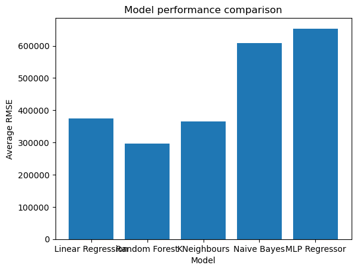

```python
plt.bar(["Linear Regression", "Random Forest", "KNeighbours", "Naive Bayes", "MLP Regressor"], [lin_score, forest_score, knn_score, gnb_score, mlp_score])
plt.title("Model performance comparison")
plt.ylabel("Average RMSE")
plt.xlabel("Model")

plt.show()
```

Based on the graph above. We can see that the Random Forest model has the lowest error score and there for perform the best. I will be using the model in the next step to fine-tune and see if these results can be further improved.

### 4. Model Fine-tuning

From here on we are going to be using the Random Forest Regressor to fit a model and make price predictions. In this section we will fine-tune the model by using GridSearch to find the best hyperparameters for the model.

```python
# GridSearch imports
from sklearn.model_selection import GridSearchCV
```

#### Set up and fit GridSearch

```python
param_grid = [{"n_estimators": [3, 10, 30], "max_features": [2, 4, 6, 8]},
              {"bootstrap": [False], "n_estimators": [3, 10], "max_features": [2, 3, 4]}]

forest_reg = RandomForestRegressor()

grid_search = GridSearchCV(forest_reg, param_grid, cv=5, scoring="neg_mean_squared_error", return_train_score=True)
```

```python
grid_search.fit(X, y)
```

```
GridSearchCV(cv=5, estimator=RandomForestRegressor(),
             param_grid=[{'max_features': [2, 4, 6, 8],
                          'n_estimators': [3, 10, 30]},
                         {'bootstrap': [False], 'max_features': [2, 3, 4],
                          'n_estimators': [3, 10]}],
             return_train_score=True, scoring='neg_mean_squared_error')
```

#### GridSearch Results analysis

```python
results = grid_search.cv_results_

for score, params in zip(results["mean_test_score"], results["params"]):
    print(f"Score: {np.sqrt(-score)} - ({params})")
```

```
Score: 387564.0989466994 - ({'max_features': 2, 'n_estimators': 3})
Score: 332551.07679821143 - ({'max_features': 2, 'n_estimators': 10})
Score: 319592.0800609586 - ({'max_features': 2, 'n_estimators': 30})
Score: 391561.48730534984 - ({'max_features': 4, 'n_estimators': 3})
Score: 331569.34241850144 - ({'max_features': 4, 'n_estimators': 10})
Score: 315577.6400489799 - ({'max_features': 4, 'n_estimators': 30})
Score: 382064.94547555933 - ({'max_features': 6, 'n_estimators': 3})
Score: 330808.0397971049 - ({'max_features': 6, 'n_estimators': 10})
Score: 315455.5168011745 - ({'max_features': 6, 'n_estimators': 30})
Score: 380043.92734307563 - ({'max_features': 8, 'n_estimators': 3})
Score: 329669.5154702696 - ({'max_features': 8, 'n_estimators': 10})
Score: 317598.9734451259 - ({'max_features': 8, 'n_estimators': 30})
Score: 387101.611422276 - ({'bootstrap': False, 'max_features': 2, 'n_estimators': 3})
Score: 330517.6592011797 - ({'bootstrap': False, 'max_features': 2, 'n_estimators': 10})
Score: 381449.53400608187 - ({'bootstrap': False, 'max_features': 3, 'n_estimators': 3})
Score: 330847.220862363 - ({'bootstrap': False, 'max_features': 3, 'n_estimators': 10})
Score: 375174.48171474715 - ({'bootstrap': False, 'max_features': 4, 'n_estimators': 3})
Score: 326686.1993785018 - ({'bootstrap': False, 'max_features': 4, 'n_estimators': 10})
```

```python
grid_search.best_params_
```

```
{'max_features': 6, 'n_estimators': 30}
```

Based on the preliminary results of the GridSearch, the best params seems to be a higher max features as well as a higher n_estimators. The bootstrap parameter set to false did seem to show some improvements when compared to it's true counterpart. Below we will increase our search params and try the grid search again.

#### Re-fitting GridSearch

```python
param_grid = [{"n_estimators": [100, 150], "max_features": [0.8, 1.0]},
              {"bootstrap": [False], "n_estimators": [150], "max_features": [1.0]}]

grid_search = GridSearchCV(forest_reg, param_grid, cv=5, scoring="neg_mean_squared_error", return_train_score=True)
```

```python
grid_search.fit(X, y)
```

```
GridSearchCV(cv=5, estimator=RandomForestRegressor(),
             param_grid=[{'max_features': [0.8, 1.0],
                          'n_estimators': [100, 150]},
                         {'bootstrap': [False], 'max_features': [1.0],
                          'n_estimators': [150]}],
             return_train_score=True, scoring='neg_mean_squared_error')
```

```python
grid_search.best_params_
```

```
{'max_features': 0.8, 'n_estimators': 100}
```

```python
np.sqrt(-grid_search.best_score_)
```

```
298969.8511257974
```

After re-running the grid search with updated parameters. The best parameters appear to be max_features of 0.8 and n_estimators of 100.

We could run more tests to fine tune this model even more but the training time is quite long and I think this would be a good stopping point for the first version of this model.

#### Feature importance

To answer the problem statement on what factors effect the housing market value in Melbourne, we are going to see what the model has deemed as the most important factors.

```python
feature_importances = grid_search.best_estimator_.feature_importances_

# Top 10 factors
sorted(zip(feature_importances, df_cleaned.columns), reverse=True)[:10]
```

```
[(0.1583558614847981, 'Regionname_Southern Metropolitan'),
 (0.14670556201517745, 'Type_h'),
 (0.11899693663990514, 'Distance'),
 (0.0913228673484137, 'Landsize'),
 (0.08178010181185552, 'Longtitude'),
 (0.07072037231666568, 'Rooms'),
 (0.06577640357808548, 'Lattitude'),
 (0.05795310134533233, 'Bathroom'),
 (0.0534815365853384, 'Bedroom2'),
 (0.03837846647209392, 'Type_u')]
```

Looking at the features above, we can see that the Southern Metropolitan region is the biggest factor in determing housing price. This seems to build trust with the model as this region covers the most wealthiest areas of Melbourne ([reference](https://en.wikipedia.org/wiki/Southern_Metropolitan_Region)).

Some other things to note:

1. As expected, the landsize (and whether it is a house or not) heavily effect the price.
2. Distance to Melbourne center plays a large role in the price of the house.
3. The age of the house does not seem to adjust the listing price to the effect that one would expect.

## Conclusion

Overall, I feel that a promising model has been developed to solve our problem statements. We were able to identify the factors that effect the market value of a property as well as predicting it's price.

I do feel like this model could be greatly improved by looking at the input dataset. This was the most challenging part of the project as the data required a lot of cleaning and imputation. Some fields like the age of the property as well as the bedrooms and bathrooms include large amounts of imputed data. We could see better model performance if we could find better imputation methods for these columns or by looking at how this data was collected and seeing if we can improve the quality of the input data.